# ALVEOLI analysis

Lina Kramer

1.03.2025

### 1. Data overview

- Exposure: high PEEP vs. low PEEP.
- Survival outcome: 28-day and 90-day survival.
- Mediator: IL-6 on days 0 and 3.

### 2. Descriptives

#### 2.1. Table 1

```r
alveoli_wide <- alveoli_long %>%
  unite("biomarker_day", biomarker, day, sep = "_") %>%
  pivot_wider(names_from = biomarker_day, values_from = conc_log10)

alveoli_wide <- merge(alveoli_wide, alveoli_surv[, c("record.id", "death_d28", "time_mort28", "death_d90", "time_mort90")], by = "record.id")


tableone::CreateTableOne(alveoli_wide, strata = c("randomized_group"), vars = c("death_d28", "death_d90", "IL6_0", "IL6_3", "sex","age", "bmi", "pfratio", "apache", "class"), factorVars = c("death_d28", "death_d90", "sex", "class"), test = F) %>% print()
```

```
##                                 Stratified by randomized_group
##                                  higher PEEP    lower PEEP
##   n                                 267            263
##   death_d28 = 1 (%)                  62 (23.2)      56 (21.3)
##   death_d90 = 1 (%)                  83 (31.1)      69 (26.2)
##   IL6_0 (mean (SD))                2.47 (0.78)    2.46 (0.73)
##   IL6_3 (mean (SD))                1.98 (0.58)    2.01 (0.58)
##   sex = male (%)                    150 (56.2)     141 (53.6)
##   age (mean (SD))                 54.00 (17.09)  48.52 (17.08)
##   bmi (mean (SD))                 27.56 (6.57)   27.12 (7.00)
##   pfratio (mean (SD))            123.16 (57.69) 132.18 (57.40)
##   apache (mean (SD))              96.48 (33.23)  91.85 (30.45)
##   class = hyper-inflammatory (%)     72 (27.0)      67 (25.5)
```

```r
tableone::CreateTableOne(alveoli_wide, strata = c("randomized_group", "class"), vars = c("death_d28", "death_d90", "IL6_0", "IL6_3", "sex","age", "bmi", "pfratio", "apache", "class"), factorVars = c("death_d28", "death_d90", "sex", "class"), test = F) %>% print()
```

```
##                                 Stratified by randomized_group:class
##                                  higher PEEP:hypo-inflammatory
##   n                                 195
##   death_d28 = 1 (%)                  35 (17.9)
##   death_d90 = 1 (%)                  51 (26.2)
##   IL6_0 (mean (SD))                2.17 (0.56)
##   IL6_3 (mean (SD))                1.89 (0.54)
##   sex = male (%)                    110 (56.4)
##   age (mean (SD))                 55.96 (16.88)
##   bmi (mean (SD))                 27.87 (6.63)
##   pfratio (mean (SD))            128.67 (58.44)
##   apache (mean (SD))              87.82 (28.80)
##   class = hyper-inflammatory (%)      0 ( 0.0)
##                                 Stratified by randomized_group:class
##                                  lower PEEP:hypo-inflammatory
##   n                                 196
##   death_d28 = 1 (%)                  27 (13.8)
##   death_d90 = 1 (%)                  36 (18.4)
##   IL6_0 (mean (SD))                2.22 (0.56)
##   IL6_3 (mean (SD))                1.88 (0.53)
##   sex = male (%)                    103 (52.6)
##   age (mean (SD))                 48.57 (17.27)
##   bmi (mean (SD))                 26.92 (6.44)
##   pfratio (mean (SD))            135.93 (58.28)
##   apache (mean (SD))              84.13 (27.43)
##   class = hyper-inflammatory (%)      0 ( 0.0)
##                                 Stratified by randomized_group:class
##                                  higher PEEP:hyper-inflammatory
##   n                                  72
##   death_d28 = 1 (%)                  27 ( 37.5)
##   death_d90 = 1 (%)                  32 ( 44.4)
##   IL6_0 (mean (SD))                3.25 (0.76)
##   IL6_3 (mean (SD))                2.25 (0.63)
##   sex = male (%)                     40 ( 55.6)
##   age (mean (SD))                 48.67 (16.63)
##   bmi (mean (SD))                 26.72 (6.38)
##   pfratio (mean (SD))            108.24 (53.15)
##   apache (mean (SD))             120.49 (33.06)
##   class = hyper-inflammatory (%)     72 (100.0)
##                                 Stratified by randomized_group:class
##                                  lower PEEP:hyper-inflammatory
##   n                                  67
##   death_d28 = 1 (%)                  29 ( 43.3)
##   death_d90 = 1 (%)                  33 ( 49.3)
##   IL6_0 (mean (SD))                3.21 (0.68)
##   IL6_3 (mean (SD))                2.38 (0.57)
##   sex = male (%)                     38 ( 56.7)
##   age (mean (SD))                 48.36 (16.63)
##   bmi (mean (SD))                 27.69 (8.47)
##   pfratio (mean (SD))            121.20 (53.68)
##   apache (mean (SD))             114.56 (27.55)
##   class = hyper-inflammatory (%)     67 (100.0)
```

#### 2.2. Missingness

For the 530 subjects who do have IL-6 measures, this is the pattern of missingness:

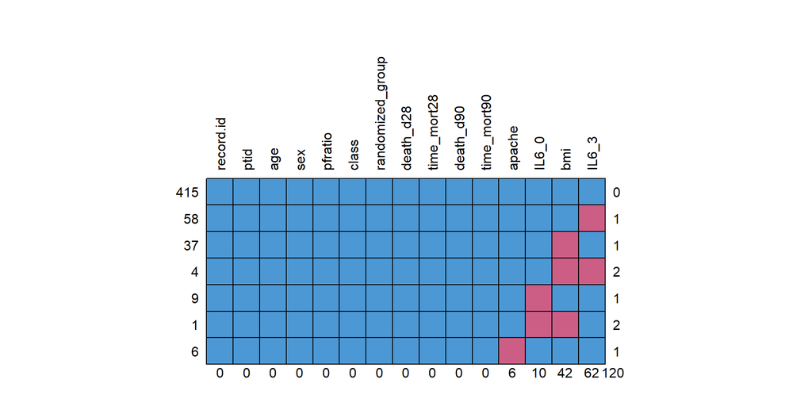

```r
missing_alveoli <- mice::md.pattern(alveoli_wide, rotate.names = TRUE, plot = TRUE)
```

#### 2.3. 28-day survival

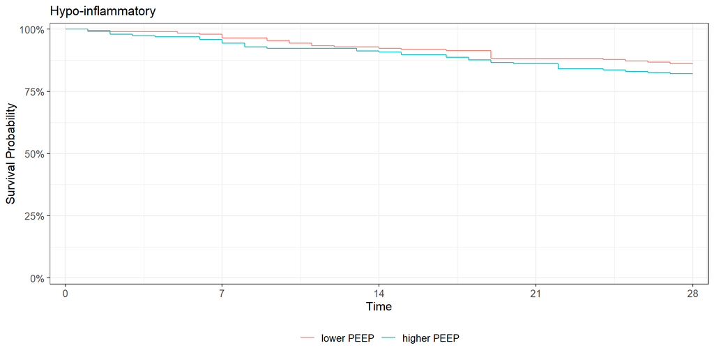

```r
# set the reference group
alveoli_surv$randomized_group <- alveoli_surv$randomized_group %>%  relevel(ref = "lower PEEP")
alveoli_long$randomized_group <- alveoli_long$randomized_group %>%  relevel(ref = "lower PEEP")

alveoli_surv$class <- alveoli_surv$class %>%  relevel(ref = "hypo-inflammatory")
alveoli_long$class <- alveoli_long$class %>%  relevel(ref = "hypo-inflammatory")

class(alveoli_surv$death_d28) <- "integer"


## 28 days

# hypo-inflammatory
alveoli_surv %>% filter(class =="hypo-inflammatory") %>%
  survfit2(Surv(time_mort28, death_d28) ~ randomized_group, data = .) %>%
  ggsurvfit()+
      scale_ggsurvfit(x_scales= list(breaks = c(0, 7, 14, 21, 28)))+
  ggtitle("Hypo-inflammatory")
```

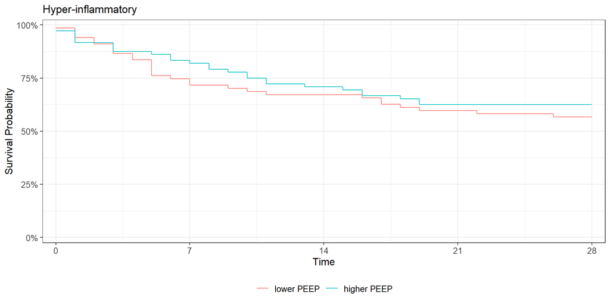

```r
# hyper-inflammatory
alveoli_surv %>% filter(class == "hyper-inflammatory") %>%
  survfit2(Surv(time_mort28, death_d28) ~ randomized_group, data = .) %>%
  ggsurvfit()+
      scale_ggsurvfit(x_scales= list(breaks = c(0, 7, 14, 21, 28)))+
  ggtitle("Hyper-inflammatory")
```

#### 2.4. 90-day survival

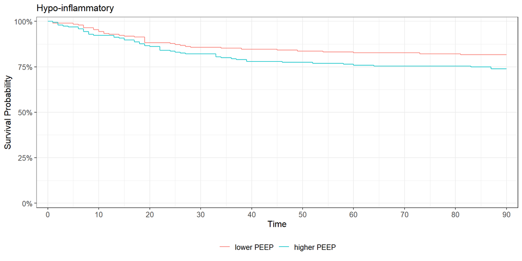

```r
class(alveoli_surv$death_d90) <- "integer"

# hypo-inflammatory
alveoli_surv %>% filter(class =="hypo-inflammatory") %>%
  survfit2(Surv(time_mort90, death_d90) ~ randomized_group, data = .) %>%
  ggsurvfit()+
      scale_ggsurvfit(x_scales= list(breaks = c(0, 10, 20, 30, 40, 50, 60, 70, 80, 90)))+
  ggtitle("Hypo-inflammatory")
```

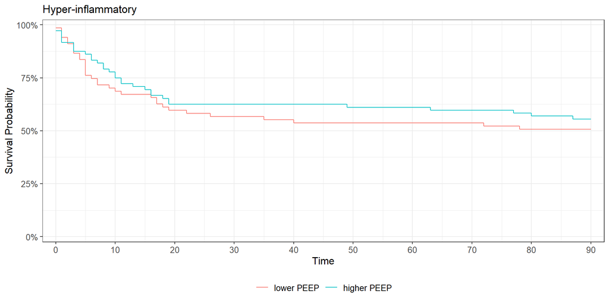

```r
# hyper-inflammatory
alveoli_surv %>% filter(class == "hyper-inflammatory") %>%
  survfit2(Surv(time_mort90, death_d90) ~ randomized_group, data = .) %>%
  ggsurvfit()+
      scale_ggsurvfit(x_scales= list(breaks = c(0, 10, 20, 30, 40, 50, 60, 70, 80, 90)))+
  ggtitle("Hyper-inflammatory")
```

#### 2.5. IL-6 over time

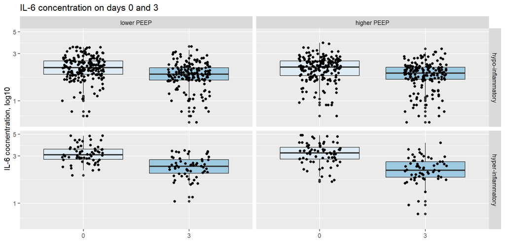

### 3. Models

#### 3.1. Linear-mixed model for IL-6 over time

##### 3.1.1. All patients

```r
# fit linear mixed mdoel
lmefit.alveoli <-lme(conc_log10~ day:randomized_group +day,
                   random = ~ day| record.id, data = alveoli_long,
                   control = lmeControl(opt = "optim"),
                   na.action = na.omit)
summary(lmefit.alveoli)
```

```
## Linear mixed-effects model fit by REML
##   Data: alveoli_long
##        AIC      BIC    logLik
##   1883.108 1917.356 -934.5538
##
## Random effects:
##  Formula: ~day | record.id
##  Structure: General positive-definite, Log-Cholesky parametrization
##             StdDev    Corr
## (Intercept) 0.7107626 (Intr)
## day         0.1825355 -0.675
## Residual    0.2564550
##
## Fixed effects:  conc_log10 ~ day:randomized_group + day
##                                      Value  Std.Error  DF   t-value p-value
## (Intercept)                      2.4667062 0.03304277 529  74.65191  0.0000
## day                             -0.1508400 0.01251259 456 -12.05506  0.0000
## day:randomized_grouphigher PEEP -0.0119792 0.01522059 456  -0.78704  0.4317
##  Correlation:
##                                 (Intr) day
## day                             -0.511
## day:randomized_grouphigher PEEP -0.002 -0.606
##
## Standardized Within-Group Residuals:
##         Min          Q1         Med          Q3         Max
## -1.30326145 -0.28079832 -0.02322622  0.25577348  1.57670118
##
## Number of Observations: 988
## Number of Groups: 530
```

```
## Approximate 95% confidence intervals
##
##  Fixed effects:
##                                       lower        est.       upper
## (Intercept)                      2.40179509  2.46670625  2.53161741
## day                             -0.17542952 -0.15084003 -0.12625054
## day:randomized_grouphigher PEEP -0.04189035 -0.01197916  0.01793203
```

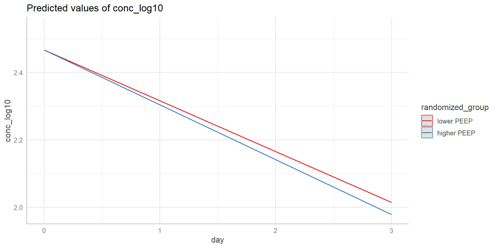

```r
library(sjPlot)
library(sjmisc)
theme_set(theme_sjplot())

plot_model(lmefit.alveoli, type = "int", terms = c("randomized_group", "day"))
```

##### 3.1.2. Hypo-inflammatory patients

```r
# hypo-inflammatory patients
lmefit.alveoli_hypo <- alveoli_long %>%
  filter(class == "hypo-inflammatory") %>%
  lme(conc_log10~ day:randomized_group + day,
      random = ~ day | record.id,
      data = .,
      control = lmeControl(opt = "optim"),
      na.action = na.omit)

summary(lmefit.alveoli_hypo)
```

```
## Linear mixed-effects model fit by REML
##   Data: .
##        AIC      BIC    logLik
##   1131.426 1163.586 -558.7128
##
## Random effects:
##  Formula: ~day | record.id
##  Structure: General positive-definite, Log-Cholesky parametrization
##             StdDev    Corr
## (Intercept) 0.5172499 (Intr)
## day         0.1540253 -0.498
## Residual    0.2097088
##
## Fixed effects:  conc_log10 ~ day:randomized_group + day
##                                      Value  Std.Error  DF  t-value p-value
## (Intercept)                      2.1968395 0.02836454 390 77.45022  0.0000
## day                             -0.1075249 0.01271585 341 -8.45597  0.0000
## day:randomized_grouphigher PEEP  0.0017632 0.01664227 341  0.10594  0.9157
##  Correlation:
##                                 (Intr) day
## day                             -0.389
## day:randomized_grouphigher PEEP -0.006 -0.646
##
## Standardized Within-Group Residuals:
##         Min          Q1         Med          Q3         Max
## -1.19315542 -0.26178045  0.01125969  0.27418628  1.46436550
##
## Number of Observations: 734
## Number of Groups: 391
```

```r
intervals(lmefit.alveoli_hypo, which = "fixed")
```

```
## Approximate 95% confidence intervals
##
##  Fixed effects:
##                                       lower         est.       upper
## (Intercept)                      2.14107299  2.196839528  2.25260606
## day                             -0.13253631 -0.107524928 -0.08251354
## day:randomized_grouphigher PEEP -0.03097127  0.001763153  0.03449758
```

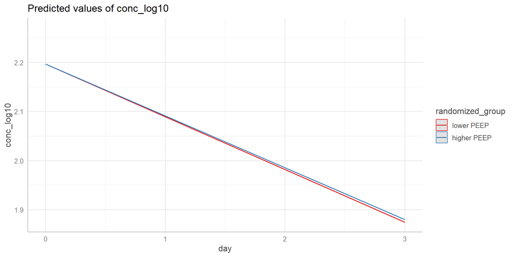

```r
plot_model(lmefit.alveoli_hypo, type = "int", terms = c("randomized_group", "day"))
```

##### 3.1.3. Hyper-inflammatory patients

```r
# hyper-inflammatory patients
lmefit.alveoli_hyper <- alveoli_long %>%
  filter(class == "hyper-inflammatory") %>%
  lme(conc_log10~  day:randomized_group + day,
      random = ~ day | record.id,
      data = .,
      control = lmeControl(opt = "optim"),
      na.action = na.omit)

summary(lmefit.alveoli_hyper)
```

```
## Linear mixed-effects model fit by REML
##   Data: .
##        AIC      BIC    logLik
##   518.8256 543.5038 -252.4128
##
## Random effects:
##  Formula: ~day | record.id
##  Structure: General positive-definite, Log-Cholesky parametrization
##             StdDev    Corr
## (Intercept) 0.6680528 (Intr)
## day         0.2152460 -0.665
## Residual    0.2652335
##
## Fixed effects:  conc_log10 ~ day:randomized_group + day
##                                     Value  Std.Error  DF  t-value p-value
## (Intercept)                      3.235636 0.06194301 138 52.23569  0.0000
## day                             -0.280463 0.02838150 113 -9.88191  0.0000
## day:randomized_grouphigher PEEP -0.045580 0.03403876 113 -1.33905  0.1832
##  Correlation:
##                                 (Intr) day
## day                             -0.516
## day:randomized_grouphigher PEEP  0.008 -0.616
##
## Standardized Within-Group Residuals:
##         Min          Q1         Med          Q3         Max
## -1.11224518 -0.29897171 -0.02083922  0.25643201  1.35874479
##
## Number of Observations: 254
## Number of Groups: 139
```

```r
intervals(lmefit.alveoli_hyper, which = "fixed")
```

```
## Approximate 95% confidence intervals
##
##  Fixed effects:
##                                      lower        est.       upper
## (Intercept)                      3.1131559  3.23563600  3.35811613
## day                             -0.3366923 -0.28046341 -0.22423454
## day:randomized_grouphigher PEEP -0.1130165 -0.04557954  0.02185738
```

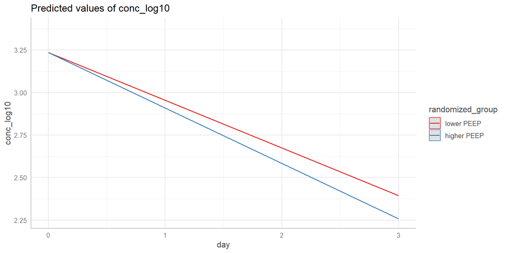

```r
plot_model(lmefit.alveoli_hyper, type = "int", terms = c("randomized_group", "day"))
```

```r
# save the interaction estimates
a_res <- get_int(lmefit.alveoli, "randomized_grouphigher PEEP")
a_res_o <- get_int(lmefit.alveoli_hypo, "randomized_grouphigher PEEP")
a_res_y <- get_int(lmefit.alveoli_hyper, "randomized_grouphigher PEEP")

a_res <- cbind(rbind(a_res, a_res_o, a_res_y),
               class = c("All", "Hypo-inflammatory", "Hyper-inflammatory"))

saveRDS(a_res, "ALVEOLI_beta_est.rds")
```

#### 3.2. Cox proportional hazards models

For 28-day and 90-day survival.

##### 3.2.1. 28-day survival: All patients

```r
# Fit cox proportional hazard model
coxfit.alveoli_28 <- coxph(Surv(time_mort28, death_d28) ~ randomized_group, data = alveoli_surv, x = TRUE)

summary(coxfit.alveoli_28)
```

```
## Call:
## coxph(formula = Surv(time_mort28, death_d28) ~ randomized_group,
##     data = alveoli_surv, x = TRUE)
##
##   n= 530, number of events= 118
##
##                                coef exp(coef) se(coef)     z Pr(>|z|)
## randomized_grouphigher PEEP 0.09433   1.09892  0.18436 0.512    0.609
##
##                             exp(coef) exp(-coef) lower .95 upper .95
## randomized_grouphigher PEEP     1.099       0.91    0.7657     1.577
##
## Concordance= 0.511  (se = 0.023 )
## Likelihood ratio test= 0.26  on 1 df,   p=0.6
## Wald test            = 0.26  on 1 df,   p=0.6
## Score (logrank) test = 0.26  on 1 df,   p=0.6
```

```r
confint(coxfit.alveoli_28) %>% exp() %>% round(3)
```

```
##                             2.5 % 97.5 %
## randomized_grouphigher PEEP 0.766  1.577
```

##### 3.2.2. 28-day survival: hypo-inflammatory patients

```r
# hypo-inflammatory
alveoli_surv_hypo <- alveoli_surv %>%
  filter(class == "hypo-inflammatory")

coxfit.alveoli_hypo_28 <- coxph(Surv(time_mort28, death_d28)~ randomized_group, data = alveoli_surv_hypo, x=TRUE)

summary(coxfit.alveoli_hypo_28)
```

```
## Call:
## coxph(formula = Surv(time_mort28, death_d28) ~ randomized_group,
##     data = alveoli_surv_hypo, x = TRUE)
##
##   n= 391, number of events= 62
##
##                               coef exp(coef) se(coef)     z Pr(>|z|)
## randomized_grouphigher PEEP 0.2899    1.3362   0.2561 1.132    0.258
##
##                             exp(coef) exp(-coef) lower .95 upper .95
## randomized_grouphigher PEEP     1.336     0.7484    0.8088     2.208
##
## Concordance= 0.537  (se = 0.032 )
## Likelihood ratio test= 1.29  on 1 df,   p=0.3
## Wald test            = 1.28  on 1 df,   p=0.3
## Score (logrank) test = 1.29  on 1 df,   p=0.3
```

##### 3.2.3. 28-day survival: hyper-inflammatory patients

```r
# hyper-inflammatory
alveoli_surv_hyper <-  alveoli_surv %>%
  filter(class == "hyper-inflammatory")

coxfit.alveoli_hyper_28 <- coxph(Surv(time_mort28, death_d28)~ randomized_group, data =  alveoli_surv_hyper, x=TRUE)

summary(coxfit.alveoli_hyper_28)
```

```
## Call:
## coxph(formula = Surv(time_mort28, death_d28) ~ randomized_group,
##     data = alveoli_surv_hyper, x = TRUE)
##
##   n= 139, number of events= 56
##
##                                coef exp(coef) se(coef)      z Pr(>|z|)
## randomized_grouphigher PEEP -0.1929    0.8246   0.2675 -0.721    0.471
##
##                             exp(coef) exp(-coef) lower .95 upper .95
## randomized_grouphigher PEEP    0.8246      1.213    0.4881     1.393
##
## Concordance= 0.525  (se = 0.034 )
## Likelihood ratio test= 0.52  on 1 df,   p=0.5
## Wald test            = 0.52  on 1 df,   p=0.5
## Score (logrank) test = 0.52  on 1 df,   p=0.5
```

##### 3.2.4. 90-day survival: All patients

```r
# Fit cox proportional hazard model
coxfit.alveoli_90 <- coxph(Surv(time_mort90, death_d90) ~ randomized_group, data = alveoli_surv, x = TRUE)

summary(coxfit.alveoli_90)
```

```
## Call:
## coxph(formula = Surv(time_mort90, death_d90) ~ randomized_group,
##     data = alveoli_surv, x = TRUE)
##
##   n= 530, number of events= 152
##
##                               coef exp(coef) se(coef)     z Pr(>|z|)
## randomized_grouphigher PEEP 0.1849    1.2031   0.1629 1.135    0.256
##
##                             exp(coef) exp(-coef) lower .95 upper .95
## randomized_grouphigher PEEP     1.203     0.8312    0.8743     1.656
##
## Concordance= 0.521  (se = 0.02 )
## Likelihood ratio test= 1.29  on 1 df,   p=0.3
## Wald test            = 1.29  on 1 df,   p=0.3
## Score (logrank) test = 1.29  on 1 df,   p=0.3
```

```r
confint(coxfit.alveoli_90) %>% exp() %>% round(3)
```

```
##                             2.5 % 97.5 %
## randomized_grouphigher PEEP 0.874  1.656
```

##### 3.2.5. 90-day survival: hypo-inflammatory

```r
# hypo-inflammatory
coxfit.alveoli_hypo_90 <- coxph(Surv(time_mort90, death_d90)~ randomized_group, data = alveoli_surv_hypo, x=TRUE)

summary(coxfit.alveoli_hypo_90)
```

```
## Call:
## coxph(formula = Surv(time_mort90, death_d90) ~ randomized_group,
##     data = alveoli_surv_hypo, x = TRUE)
##
##   n= 391, number of events= 87
##
##                               coef exp(coef) se(coef)     z Pr(>|z|)
## randomized_grouphigher PEEP 0.3928    1.4811   0.2177 1.804   0.0712 .
## ---
## Signif. codes:  0 '***' 0.001 '**' 0.01 '*' 0.05 '.' 0.1 ' ' 1
##
##                             exp(coef) exp(-coef) lower .95 upper .95
## randomized_grouphigher PEEP     1.481     0.6752    0.9667     2.269
##
## Concordance= 0.548  (se = 0.027 )
## Likelihood ratio test= 3.31  on 1 df,   p=0.07
## Wald test            = 3.26  on 1 df,   p=0.07
## Score (logrank) test = 3.3  on 1 df,   p=0.07
```

##### 3.2.6. 90-day survival: hyper-inflammatory

```r
# hyper-inflammatory
coxfit.alveoli_hyper_90<-  coxph(Surv(time_mort90, death_d90)~ randomized_group, data = alveoli_surv_hyper, x=TRUE)

summary(coxfit.alveoli_hyper_90)
```

```
## Call:
## coxph(formula = Surv(time_mort90, death_d90) ~ randomized_group,
##     data = alveoli_surv_hyper, x = TRUE)
##
##   n= 139, number of events= 65
##
##                                coef exp(coef) se(coef)      z Pr(>|z|)
## randomized_grouphigher PEEP -0.1623    0.8502   0.2482 -0.654    0.513
##
##                             exp(coef) exp(-coef) lower .95 upper .95
## randomized_grouphigher PEEP    0.8502      1.176    0.5227     1.383
##
## Concordance= 0.523  (se = 0.032 )
## Likelihood ratio test= 0.43  on 1 df,   p=0.5
## Wald test            = 0.43  on 1 df,   p=0.5
## Score (logrank) test = 0.43  on 1 df,   p=0.5
```

#### 3.3. Joint models

Using 28- and 90-day survival as endpoints.

Fit joint models for:

- Survival to day 28 of 1) All patients, 2)hypo-, & 3) hyper-inflammatory.
- Survival to day 90: 4) All patients, 5) hypo-, & 6) hyper-inflammatory.

```r
################################################################################
### Joint models ###############################################################
################################################################################

require(JMbayes2)
set.seed(15)

### 28-day survival ############################################################

# All patients -----------------------------------------------------------------

## fit joint model
jointfit.alveoli_28<- JMbayes2::jm(coxfit.alveoli_28,
                                   lmefit.alveoli,
                                   time_var = "day", n_iter = 200000L,
                                   n_burnin = 5000L, n_chains = 2L,
                                   n_thin = 7L, cores= 2)

saveRDS(jointfit.alveoli_28, "jointfit_alveoli_28.rds")

# hypo-inflammatory patients ---------------------------------------------------

## fit joint model
jointfit.alveoli_hypo_28<- JMbayes2::jm(coxfit.alveoli_hypo_28,
                                        lmefit.alveoli_hypo,
                                        time_var = "day", n_iter = 200000L,
                                   n_burnin = 5000L, n_chains = 2L,
                                   n_thin = 7L, cores= 2)

saveRDS(jointfit.alveoli_hypo_28, "jointfit_alveoli_hypo_28.rds")

# hyper-inflammatory patients --------------------------------------------------

## fit joint model
jointfit.alveoli_hyper_28<- JMbayes2::jm(coxfit.alveoli_hyper_28,
                                         lmefit.alveoli_hyper,
                                         time_var = "day", n_iter = 200000L,
                                   n_burnin = 5000L, n_chains = 2L,
                                   n_thin = 7L, cores= 2)

saveRDS(jointfit.alveoli_hyper_28, "jointfit_alveoli_hyper_28.rds")

### 90-day survival ############################################################

# All patients -----------------------------------------------------------------

## fit joint model
jointfit.alveoli_90<- JMbayes2::jm(coxfit.alveoli_90,
                                   lmefit.alveoli,
                                   time_var = "day", n_iter = 200000L,
                                   n_burnin = 5000L, n_chains = 2L,
                                   n_thin = 7L, cores= 2)

saveRDS(jointfit.alveoli_90, "jointfit_alveoli_90.rds")


# hypo-inflammatory patients ---------------------------------------------------

## fit joint model
jointfit.alveoli_hypo_90<- JMbayes2::jm(coxfit.alveoli_hypo_90,
                                        lmefit.alveoli_hypo,
                                        time_var = "day", n_iter = 200000L,
                                   n_burnin = 5000L, n_chains = 2L,
                                   n_thin = 7L, cores= 2)

saveRDS(jointfit.alveoli_hypo_90, "jointfit_alveoli_hypo_90.rds")

# hyper-inflammatory patients --------------------------------------------------

## fit joint model
jointfit.alveoli_hyper_90<- JMbayes2::jm(coxfit.alveoli_hyper_90,
                                         lmefit.alveoli_hyper,
                                         time_var = "day",n_iter = 200000L,
                                   n_burnin = 5000L, n_chains = 2L,
                                   n_thin = 7L, cores= 2)

saveRDS(jointfit.alveoli_hyper_90, "jointfit_alveoli_hyper_90.rds")
```

```r
jointfit.alveoli_28 <- readRDS("jointfit_alveoli_28.rds")
jointfit.alveoli_hypo_28 <- readRDS("jointfit_alveoli_hypo_28.rds")
jointfit.alveoli_hyper_28 <- readRDS("jointfit_alveoli_hyper_28.rds")
jointfit.alveoli_hypo_90 <- readRDS("jointfit_alveoli_hypo_90.rds")
jointfit.alveoli_hyper_90 <- readRDS("jointfit_alveoli_hyper_90.rds")
jointfit.alveoli_90 <- readRDS("jointfit_alveoli_90.rds")
```

##### 3.3.1. 28-day endpoint: All patients

```
##
## Call:
## JMbayes2::jm(Surv_object = coxfit.alveoli_28, Mixed_objects = lmefit.alveoli,
##     time_var = "day", n_iter = 200000L, n_burnin = 5000L, n_chains = 2L,
##     n_thin = 7L, cores = 2)
##
## Data Descriptives:
## Number of Groups: 530        Number of events: 118 (22.3%)
## Number of Observations:
##   conc_log10: 988
##
##                  DIC     WAIC      LPML
## marginal    3124.969 3189.944 -1618.418
## conditional 2451.933 2221.305 -1651.252
##
## Random-effects covariance matrix:
##
##        StdDev   Corr
## (Intr) 0.5734 (Intr)
## day    0.0604 -0.5645
##
## Survival Outcome:
##                               Mean  StDev    2.5%  97.5%      P   Rhat
## randomized_grouphigher PEEP 0.1468 0.3111 -0.4667 0.7559 0.6354 1.0002
## value(conc_log10)           1.7339 0.3228  1.1053 2.3672 0.0000 1.0036
##
## Longitudinal Outcome: conc_log10 (family = gaussian, link = identity)
##                Mean  StDev    2.5%   97.5%     P   Rhat
## (Intercept)  2.4647 0.0313  2.4030  2.5264 0.000 1.0000
## day         -0.1521 0.0113 -0.1739 -0.1297 0.000 1.0001
## d:_P        -0.0029 0.0119 -0.0264  0.0203 0.808 1.0001
## sigma        0.4298 0.0163  0.3979  0.4621 0.000 1.0000
##
## MCMC summary:
## chains: 2
## iterations per chain: 200000
## burn-in per chain: 5000
## thinning: 7
## time: 24.3 min
```

##### 3.3.2. 28-day endpoint: hypo-inflammatory

```
##
## Call:
## JMbayes2::jm(Surv_object = coxfit.alveoli_hypo_28, Mixed_objects = lmefit.alveoli_hypo,
##     time_var = "day", n_iter = 200000L, n_burnin = 5000L, n_chains = 2L,
##     n_thin = 7L, cores = 2)
##
## Data Descriptives:
## Number of Groups: 391        Number of events: 62 (15.9%)
## Number of Observations:
##   conc_log10: 734
##
##                  DIC     WAIC      LPML
## marginal    1811.318 1937.812 -1517.725
## conditional 1348.974 1252.971 -1025.937
##
## Random-effects covariance matrix:
##
##        StdDev   Corr
## (Intr) 0.4380 (Intr)
## day    0.0816 -0.3897
##
## Survival Outcome:
##                               Mean  StDev    2.5%  97.5%      P   Rhat
## randomized_grouphigher PEEP 0.2929 0.3708 -0.4245 1.0254 0.4333 1.0000
## value(conc_log10)           0.7645 0.5173  0.0440 1.9425 0.0289 1.0051
##
## Longitudinal Outcome: conc_log10 (family = gaussian, link = identity)
##                Mean  StDev    2.5%   97.5%      P   Rhat
## (Intercept)  2.1964 0.0284  2.1409  2.2522 0.0000 1.0001
## day         -0.1067 0.0123 -0.1309 -0.0825 0.0000 1.0003
## d:_P         0.0016 0.0157 -0.0296  0.0323 0.9165 1.0000
## sigma        0.3470 0.0375  0.2438  0.3983 0.0000 1.0047
##
## MCMC summary:
## chains: 2
## iterations per chain: 200000
## burn-in per chain: 5000
## thinning: 7
## time: 19 min
```

##### 3.3.3. 28-day endpoint: hyper-inflammatory

```
##
## Call:
## JMbayes2::jm(Surv_object = coxfit.alveoli_hyper_28, Mixed_objects = lmefit.alveoli_hyper,
##     time_var = "day", n_iter = 200000L, n_burnin = 5000L, n_chains = 2L,
##     n_thin = 7L, cores = 2)
##
## Data Descriptives:
## Number of Groups: 139        Number of events: 56 (40.3%)
## Number of Observations:
##   conc_log10: 254
##
##                   DIC      WAIC       LPML
## marginal    1128.7818 1417.7325 -2913.5840
## conditional  995.0243  977.3617  -631.6249
##
## Random-effects covariance matrix:
##
##        StdDev   Corr
## (Intr) 0.5865 (Intr)
## day    0.1716 -0.5493
##
## Survival Outcome:
##                                Mean  StDev    2.5%  97.5%      P   Rhat
## randomized_grouphigher PEEP -0.0910 0.3734 -0.8103 0.6459 0.8071 1.0001
## value(conc_log10)            0.4705 0.2968  0.0771 1.2019 0.0096 1.0046
##
## Longitudinal Outcome: conc_log10 (family = gaussian, link = identity)
##                Mean  StDev    2.5%   97.5%      P   Rhat
## (Intercept)  3.2352 0.0599  3.1182  3.3534 0.0000 1.0000
## day         -0.2794 0.0286 -0.3357 -0.2238 0.0000 1.0001
## d:_P        -0.0412 0.0352 -0.1113  0.0275 0.2416 1.0000
## sigma        0.3629 0.0990  0.1394  0.5151 0.0000 1.0054
##
## MCMC summary:
## chains: 2
## iterations per chain: 200000
## burn-in per chain: 5000
## thinning: 7
## time: 10.7 min
```

##### 3.3.4. 90-day endpoint: All patients

```
##
## Call:
## JMbayes2::jm(Surv_object = coxfit.alveoli_90, Mixed_objects = lmefit.alveoli,
##     time_var = "day", n_iter = 200000L, n_burnin = 5000L, n_chains = 2L,
##     n_thin = 7L, cores = 2)
##
## Data Descriptives:
## Number of Groups: 530        Number of events: 152 (28.7%)
## Number of Observations:
##   conc_log10: 988
##
##                  DIC        WAIC        LPML
## marginal    4593.322 90276195.11 -1184234.97
## conditional 3105.255     3073.19    -2642.37
##
## Random-effects covariance matrix:
##
##        StdDev   Corr
## (Intr) 0.7051 (Intr)
## day    0.1800 -0.6575
##
## Survival Outcome:
##                               Mean  StDev    2.5%  97.5%      P   Rhat
## randomized_grouphigher PEEP 0.1943 0.2126 -0.2193 0.6063 0.3700 1.0000
## value(conc_log10)           0.0705 0.0522  0.0143 0.1845 0.0117 1.0217
##
## Longitudinal Outcome: conc_log10 (family = gaussian, link = identity)
##                Mean  StDev    2.5%   97.5%      P   Rhat
## (Intercept)  2.4658 0.0329  2.4014  2.5310 0.0000 1.0000
## day         -0.1509 0.0126 -0.1758 -0.1264 0.0000 1.0001
## d:_P        -0.0109 0.0154 -0.0410  0.0194 0.4781 1.0000
## sigma        0.2481 0.0823  0.0938  0.3973 0.0000 1.0049
##
## MCMC summary:
## chains: 2
## iterations per chain: 200000
## burn-in per chain: 5000
## thinning: 7
## time: 23.9 min
```

##### 3.3.5. 90-day endpoint: hypo-inflammatory

```
##
## Call:
## JMbayes2::jm(Surv_object = coxfit.alveoli_hypo_90, Mixed_objects = lmefit.alveoli_hypo,
##     time_var = "day", n_iter = 200000L, n_burnin = 5000L, n_chains = 2L,
##     n_thin = 7L, cores = 2)
##
## Data Descriptives:
## Number of Groups: 391        Number of events: 87 (22.3%)
## Number of Observations:
##   conc_log10: 734
##
##                  DIC         WAIC        LPML
## marginal    2387.844     33126.26   -10497.92
## conditional 1872.224 403705365.83 -8882617.67
##
## Random-effects covariance matrix:
##
##        StdDev   Corr
## (Intr) 0.4657 (Intr)
## day    0.1100 -0.4319
##
## Survival Outcome:
##                               Mean  StDev    2.5%  97.5%      P   Rhat
## randomized_grouphigher PEEP 0.3617 0.3095 -0.2407 0.9620 0.2444 1.0009
## value(conc_log10)           0.2571 0.1673  0.0475 0.6693 0.0032 1.0153
##
## Longitudinal Outcome: conc_log10 (family = gaussian, link = identity)
##                Mean  StDev    2.5%   97.5%      P   Rhat
## (Intercept)  2.1966 0.0285  2.1408  2.2526 0.0000 1.0000
## day         -0.1084 0.0125 -0.1330 -0.0841 0.0000 1.0004
## d:_P         0.0043 0.0159 -0.0275  0.0354 0.7826 1.0008
## sigma        0.3048 0.0627  0.1387  0.3822 0.0000 1.0768
##
## MCMC summary:
## chains: 2
## iterations per chain: 200000
## burn-in per chain: 5000
## thinning: 7
## time: 18.3 min
```

##### 3.3.6. 90-day endpoint: hyper-inflammatory

```
##
## Call:
## JMbayes2::jm(Surv_object = coxfit.alveoli_hyper_90, Mixed_objects = lmefit.alveoli_hyper,
##     time_var = "day", n_iter = 200000L, n_burnin = 5000L, n_chains = 2L,
##     n_thin = 7L, cores = 2)
##
## Data Descriptives:
## Number of Groups: 139        Number of events: 65 (46.8%)
## Number of Observations:
##   conc_log10: 254
##
##                  DIC     WAIC      LPML
## marginal    1217.064 1346.907 -2587.851
## conditional 1164.614 1127.975 -1613.140
##
## Random-effects covariance matrix:
##
##        StdDev   Corr
## (Intr) 0.5944 (Intr)
## day    0.1767 -0.5591
##
## Survival Outcome:
##                                Mean  StDev    2.5%  97.5%      P   Rhat
## randomized_grouphigher PEEP -0.1348 0.3503 -0.8166 0.5420 0.7051 1.0002
## value(conc_log10)            0.2064 0.1251  0.0188 0.4812 0.0254 1.0179
##
## Longitudinal Outcome: conc_log10 (family = gaussian, link = identity)
##                Mean  StDev    2.5%   97.5%      P   Rhat
## (Intercept)  3.2345 0.0602  3.1169  3.3531 0.0000 1.0003
## day         -0.2816 0.0287 -0.3384 -0.2258 0.0000 1.0006
## d:_P        -0.0400 0.0349 -0.1089  0.0285 0.2493 1.0002
## sigma        0.3596 0.0821  0.1688  0.4950 0.0000 1.0051
##
## MCMC summary:
## chains: 2
## iterations per chain: 200000
## burn-in per chain: 5000
## thinning: 7
## time: 10.9 min
```

### 4. Results

#### 4.1. Indirect, direct, and total effects

Of randomized_grouphigher PEEP through IL6 on mortality for:

- 1. All patients; 28-day endpoint.
- 2. Hypo-inflammatory patients; 28-day endpoint.
- 3. Hyper-inflammatory patients; 28-day endpoint.
- 4. All patients; 90-day endpoint.
- 5. Hypo-inflammatory patients; 90-day endpoint.
- 6. Hyper-inflammatory patients; 90-day endpoint.

```r
# 1
res28 <- get_effects(jointfit.alveoli_28, coxfit.alveoli_28,
                     "randomized_grouphigher PEEP") %>%
  cbind(endpoint ="28-day endpoint",
        class = "All")

res28
```

```
##           effect          est    CI_lower   CI_upper        endpoint class
## 1         direct  0.146798345 -0.46666182 0.75588531 28-day endpoint   All
## 2       indirect -0.005016787 -0.04391935 0.03604401 28-day endpoint   All
## 3 total (Cox-PH)  0.094329634 -0.26700166 0.45566093 28-day endpoint   All
## 4     total (JM)  0.141781558 -0.44823468 0.72979435 28-day endpoint   All
```

```r
# 2
res28_o <- get_effects(jointfit.alveoli_hypo_28, coxfit.alveoli_hypo_28,
                     "randomized_grouphigher PEEP") %>%
  cbind(endpoint ="28-day endpoint",
        class = "Hypo-inflammatory")
res28_o
```

```
##           effect         est    CI_lower   CI_upper        endpoint
## 1         direct 0.292887873 -0.42452063 1.02536339 28-day endpoint
## 2       indirect 0.001209979 -0.02781138 0.03055047 28-day endpoint
## 3 total (Cox-PH) 0.289855366 -0.21218466 0.79189539 28-day endpoint
## 4     total (JM) 0.294097852 -0.41440646 1.01685770 28-day endpoint
##               class
## 1 Hypo-inflammatory
## 2 Hypo-inflammatory
## 3 Hypo-inflammatory
## 4 Hypo-inflammatory
```

```r
# 3
res28_y <- get_effects(jointfit.alveoli_hyper_28, coxfit.alveoli_hyper_28,
                     "randomized_grouphigher PEEP") %>%
  cbind(endpoint ="28-day endpoint",
        class = "Hyper-inflammatory")
res28_y
```

```
##           effect         est    CI_lower   CI_upper        endpoint
## 1         direct -0.09104104 -0.81029965 0.64585082 28-day endpoint
## 2       indirect -0.01939739 -0.07013073 0.01384712 28-day endpoint
## 3 total (Cox-PH) -0.19285017 -0.71715984 0.33145949 28-day endpoint
## 4     total (JM) -0.11043842 -0.82158921 0.61508841 28-day endpoint
##                class
## 1 Hyper-inflammatory
## 2 Hyper-inflammatory
## 3 Hyper-inflammatory
## 4 Hyper-inflammatory
```

```r
# 4
res90 <- get_effects(jointfit.alveoli_90, coxfit.alveoli_90,
                     "randomized_grouphigher PEEP") %>%
  cbind(endpoint ="90-day endpoint",
        class = "All")

res90
```

```
##           effect           est   CI_lower    CI_upper        endpoint class
## 1         direct  0.1942755572 -0.2192538 0.606266019 90-day endpoint   All
## 2       indirect -0.0007667985 -0.0035573 0.001573161 90-day endpoint   All
## 3 total (Cox-PH)  0.1849312578 -0.1343866 0.504249119 90-day endpoint   All
## 4     total (JM)  0.1935087587 -0.2197161 0.605538379 90-day endpoint   All
```

```r
# 5
res90_o <- get_effects(jointfit.alveoli_hypo_90, coxfit.alveoli_hypo_90,
                     "randomized_grouphigher PEEP") %>%
  cbind(endpoint ="90-day endpoint",
        class = "Hypo-inflammatory")
res90_o
```

```
##           effect         est     CI_lower  CI_upper        endpoint
## 1         direct 0.361746789 -0.240727781 0.9620428 90-day endpoint
## 2       indirect 0.001097181 -0.007022626 0.0130480 90-day endpoint
## 3 total (Cox-PH) 0.392771859 -0.033913099 0.8194568 90-day endpoint
## 4     total (JM) 0.362843971 -0.237009082 0.9619057 90-day endpoint
##               class
## 1 Hypo-inflammatory
## 2 Hypo-inflammatory
## 3 Hypo-inflammatory
## 4 Hypo-inflammatory
```

```r
# 6
res90_y <- get_effects(jointfit.alveoli_hyper_90, coxfit.alveoli_hyper_90,
                     "randomized_grouphigher PEEP") %>%
  cbind(endpoint ="90-day endpoint",
        class = "Hyper-inflammatory")
res90_y
```

```
##           effect          est    CI_lower    CI_upper        endpoint
## 1         direct -0.134820756 -0.81662693 0.541989202 90-day endpoint
## 2       indirect -0.008259036 -0.03036041 0.006737194 90-day endpoint
## 3 total (Cox-PH) -0.162310698 -0.64873907 0.324117675 90-day endpoint
## 4     total (JM) -0.143079792 -0.82069800 0.531492313 90-day endpoint
##                class
## 1 Hyper-inflammatory
## 2 Hyper-inflammatory
## 3 Hyper-inflammatory
## 4 Hyper-inflammatory
```

```r
# save together

res <- rbind(res28, res28_o, res28_y, res90, res90_o, res90_y)

saveRDS(res, "alveoli_res.rds")
```

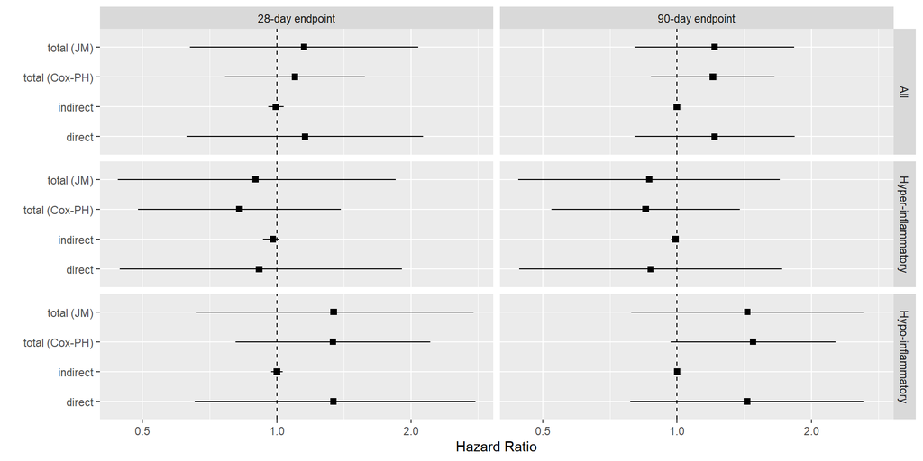

```r
res %>%
  ggplot(aes(y = effect))+
  theme_grey()+
  geom_point(aes(x=exp(est)), shape=15, size=2) +
  geom_linerange(aes(xmin=exp(CI_lower), xmax=exp(CI_upper))) +
   geom_vline(xintercept = 1, linetype="dashed") +
  labs(x="Hazard Ratio", y= "")+
  scale_x_continuous(trans = "log2")+
  facet_grid(class~endpoint)
```

#### 4.4. Conclusions

- From lme and the joint models, we can conclude that there is no effect of higher PEEP over time on IL-6.
- From joint model we conclude 1) that there is no direct effect of higher PEEP on survival when controlling for IL-6, and 2) there is an association between IL-6 and survival.

### 5. Model checks

#### 5.1. Longitudinal submodel

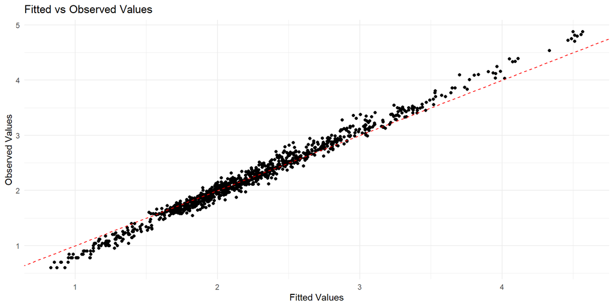

```r
# get fitted values
fitted_values<- fitted(lmefit.alveoli)
alveoli_long <- alveoli_long %>%  drop_na(conc_log10)

# plot observed vs fitted values
ggplot(data = alveoli_long, aes(x = fitted_values, y = conc_log10)) +
  geom_point() +
  geom_abline(slope = 1, intercept = 0, linetype = "dashed", color = "red") +  # Line of perfect fit
  labs(x = "Fitted Values", y = "Observed Values") +
  ggtitle("Fitted vs Observed Values") +
  theme_minimal()
```

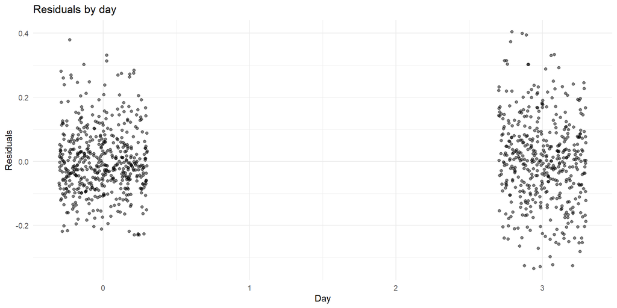

```r
# get residuals
residuals_values <- resid(lmefit.alveoli)


# plot residuals vs time
ggplot(alveoli_long, aes(x = day, y = residuals_values)) +
  geom_jitter(width = 0.3, alpha = 0.5) +
  labs(x = "Day", y = "Residuals") +
  ggtitle("Residuals by day") +
  theme_minimal()
```

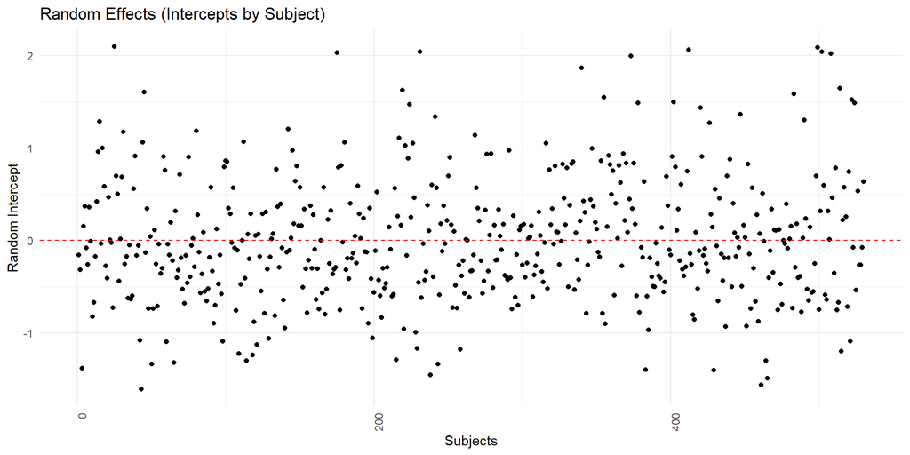

```r
# get random effects
random_effects <- ranef(lmefit.alveoli)

#plot random effects
ggplot(random_effects, aes(x = c(1:nrow(alveoli_surv)), y = `(Intercept)`)) +
  geom_point() +
  geom_hline(yintercept = 0, linetype = "dashed", color = "red") +
  labs(x = "Subjects", y = "Random Intercept") +
  ggtitle("Random Effects (Intercepts by Subject)") +
  theme_minimal() +
  theme(axis.text.x = element_text(angle = 90, hjust = 1))
```

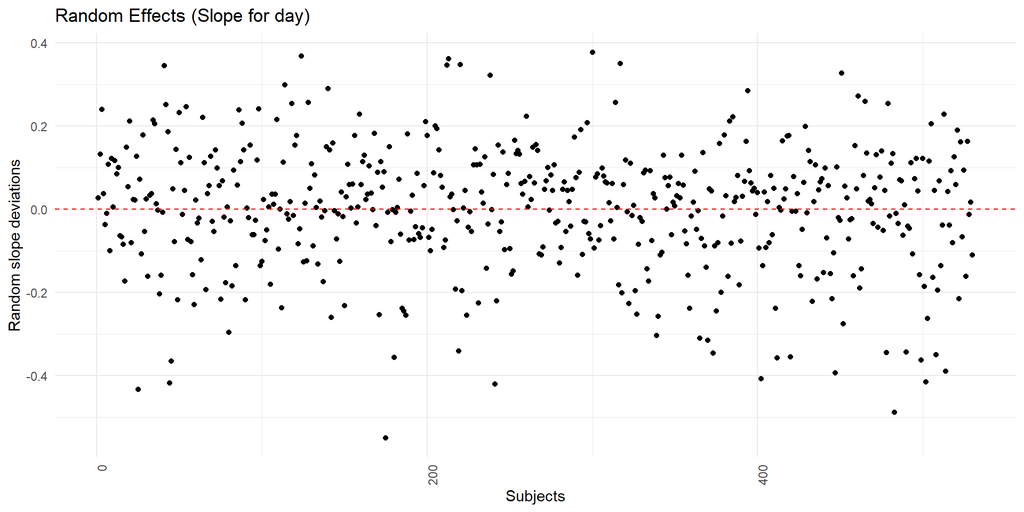

```r
#plot random effects
ggplot(random_effects, aes(x = c(1:nrow(alveoli_surv)), y = `day`)) +
  geom_point() +
  geom_hline(yintercept = 0, linetype = "dashed", color = "red") +
  labs(x = "Subjects", y = "Random slope deviations") +
  ggtitle("Random Effects (Slope for day)") +
  theme_minimal() +
  theme(axis.text.x = element_text(angle = 90, hjust = 1))
```

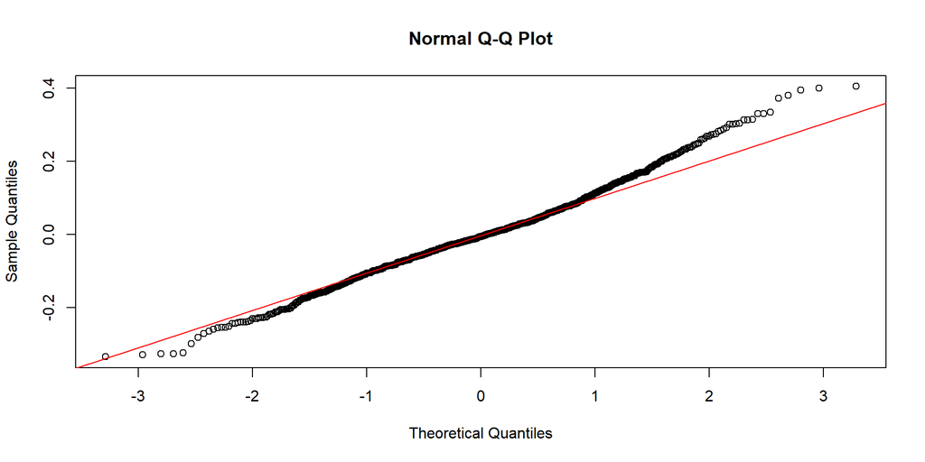

```r
# qq plot for residuals
qqnorm(resid(lmefit.alveoli))

qqline(resid(lmefit.alveoli), col = "red")
```

#### 5.2 Survival submodel 28-day endpoint

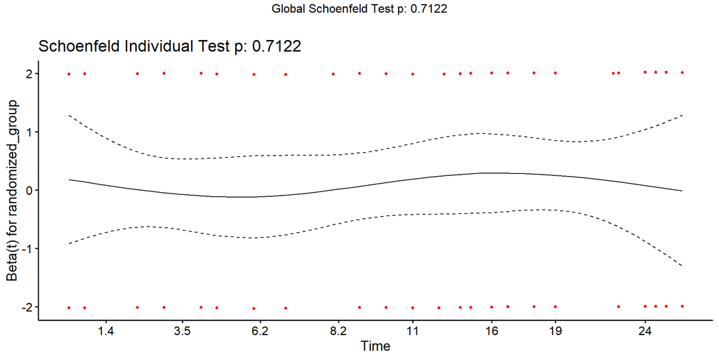

```r
test.ph <- cox.zph(coxfit.alveoli_28)
survminer::ggcoxzph(test.ph)
```

#### 5.3 Survival submodel 28-day endpoint hyper

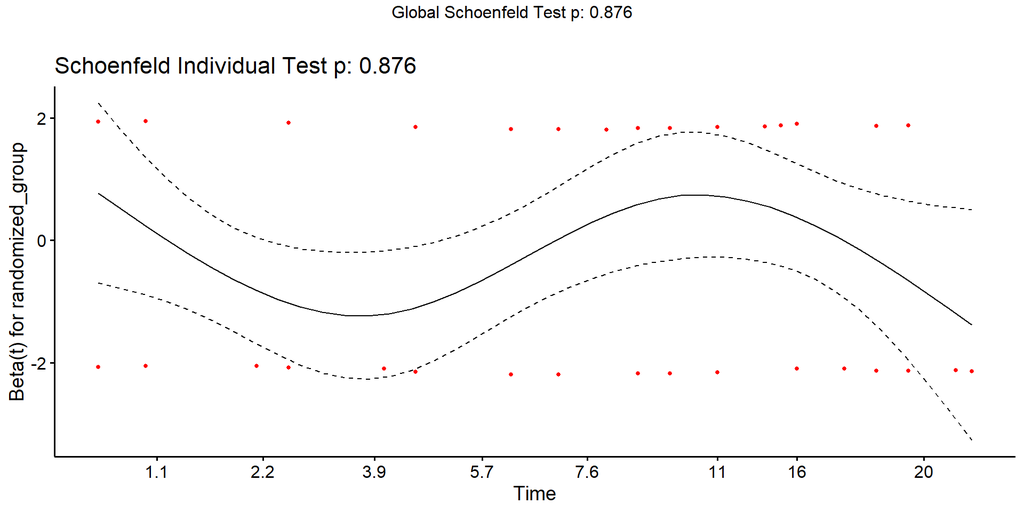

```r
test.ph <- cox.zph(coxfit.alveoli_hyper_28)
survminer::ggcoxzph(test.ph)
```

#### 5.4 Survival submodel 28-day endpoint hypo

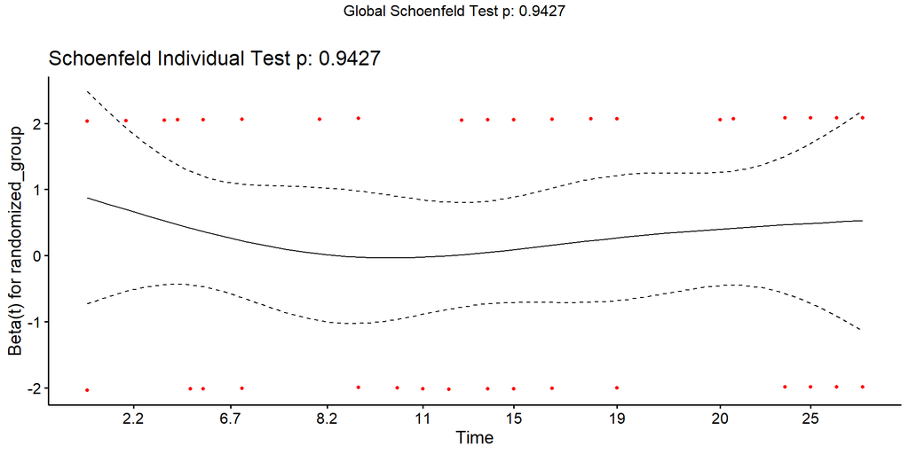

```r
test.ph <- cox.zph(coxfit.alveoli_hypo_28)
survminer::ggcoxzph(test.ph)
```